# Risk Factor Analysis

## Outcome Variable

**Outcome Variable:** sstunted

## Predictor Variables

**Intervention Variable:** birthlen

**Adjustment Set:**

unadjusted

## Stratifying Variables

The analysis was stratified on these variable(s):

- agecat
- studyid

The following strata were considered:

- agecat: 12 months, studyid: ki0047075b-MAL-ED
- agecat: 12 months, studyid: ki1000108-CMC-V-BCS-2002
- agecat: 12 months, studyid: ki1000108-IRC
- agecat: 12 months, studyid: ki1017093b-PROVIDE
- agecat: 12 months, studyid: ki1017093c-NIH-Crypto
- agecat: 12 months, studyid: ki1101329-Keneba
- agecat: 12 months, studyid: ki1126311-ZVITAMBO
- agecat: 12 months, studyid: ki1135781-COHORTS
- agecat: 18 months, studyid: ki0047075b-MAL-ED
- agecat: 18 months, studyid: ki1000108-CMC-V-BCS-2002
- agecat: 18 months, studyid: ki1000108-IRC
- agecat: 18 months, studyid: ki1017093b-PROVIDE
- agecat: 18 months, studyid: ki1017093c-NIH-Crypto
- agecat: 18 months, studyid: ki1101329-Keneba
- agecat: 18 months, studyid: ki1126311-ZVITAMBO
- agecat: 18 months, studyid: ki1135781-COHORTS
- agecat: 24 months, studyid: ki0047075b-MAL-ED
- agecat: 24 months, studyid: ki1000108-CMC-V-BCS-2002
- agecat: 24 months, studyid: ki1000108-IRC
- agecat: 24 months, studyid: ki1017093b-PROVIDE
- agecat: 24 months, studyid: ki1017093c-NIH-Crypto
- agecat: 24 months, studyid: ki1101329-Keneba
- agecat: 24 months, studyid: ki1126311-ZVITAMBO
- agecat: 24 months, studyid: ki1135781-COHORTS
- agecat: 3 months, studyid: ki0047075b-MAL-ED
- agecat: 3 months, studyid: ki1000108-CMC-V-BCS-2002
- agecat: 3 months, studyid: ki1000108-IRC
- agecat: 3 months, studyid: ki1017093b-PROVIDE
- agecat: 3 months, studyid: ki1017093c-NIH-Crypto
- agecat: 3 months, studyid: ki1101329-Keneba
- agecat: 3 months, studyid: ki1126311-ZVITAMBO
- agecat: 3 months, studyid: ki1135781-COHORTS
- agecat: 6 months, studyid: ki0047075b-MAL-ED
- agecat: 6 months, studyid: ki1000108-CMC-V-BCS-2002
- agecat: 6 months, studyid: ki1000108-IRC
- agecat: 6 months, studyid: ki1017093b-PROVIDE
- agecat: 6 months, studyid: ki1017093c-NIH-Crypto
- agecat: 6 months, studyid: ki1101329-Keneba
- agecat: 6 months, studyid: ki1126311-ZVITAMBO
- agecat: 6 months, studyid: ki1135781-COHORTS
- agecat: 9 months, studyid: ki0047075b-MAL-ED
- agecat: 9 months, studyid: ki1000108-CMC-V-BCS-2002
- agecat: 9 months, studyid: ki1000108-IRC
- agecat: 9 months, studyid: ki1017093b-PROVIDE
- agecat: 9 months, studyid: ki1017093c-NIH-Crypto
- agecat: 9 months, studyid: ki1101329-Keneba
- agecat: 9 months, studyid: ki1126311-ZVITAMBO
- agecat: 9 months, studyid: ki1135781-COHORTS
- agecat: Birth, studyid: ki0047075b-MAL-ED
- agecat: Birth, studyid: ki1000108-CMC-V-BCS-2002
- agecat: Birth, studyid: ki1000108-IRC
- agecat: Birth, studyid: ki1017093c-NIH-Crypto
- agecat: Birth, studyid: ki1101329-Keneba
- agecat: Birth, studyid: ki1126311-ZVITAMBO
- agecat: Birth, studyid: ki1135781-COHORTS

### Dropped Strata

Some strata were dropped due to rare outcomes:

- agecat: Birth, studyid: ki0047075b-MAL-ED
- agecat: Birth, studyid: ki1000108-CMC-V-BCS-2002
- agecat: Birth, studyid: ki1000108-IRC
- agecat: Birth, studyid: ki1017093c-NIH-Crypto
- agecat: Birth, studyid: ki1101329-Keneba
- agecat: Birth, studyid: ki1126311-ZVITAMBO
- agecat: Birth, studyid: ki1135781-COHORTS
- agecat: 3 months, studyid: ki0047075b-MAL-ED
- agecat: 3 months, studyid: ki1000108-CMC-V-BCS-2002
- agecat: 3 months, studyid: ki1000108-IRC
- agecat: 3 months, studyid: ki1017093b-PROVIDE
- agecat: 3 months, studyid: ki1017093c-NIH-Crypto
- agecat: 3 months, studyid: ki1101329-Keneba
- agecat: 3 months, studyid: ki1126311-ZVITAMBO
- agecat: 3 months, studyid: ki1135781-COHORTS
- agecat: 6 months, studyid: ki0047075b-MAL-ED
- agecat: 6 months, studyid: ki1000108-CMC-V-BCS-2002
- agecat: 6 months, studyid: ki1000108-IRC
- agecat: 6 months, studyid: ki1017093b-PROVIDE
- agecat: 6 months, studyid: ki1017093c-NIH-Crypto
- agecat: 6 months, studyid: ki1126311-ZVITAMBO
- agecat: 9 months, studyid: ki0047075b-MAL-ED
- agecat: 9 months, studyid: ki1000108-CMC-V-BCS-2002
- agecat: 9 months, studyid: ki1000108-IRC
- agecat: 9 months, studyid: ki1017093b-PROVIDE
- agecat: 9 months, studyid: ki1017093c-NIH-Crypto
- agecat: 12 months, studyid: ki0047075b-MAL-ED
- agecat: 12 months, studyid: ki1000108-CMC-V-BCS-2002
- agecat: 12 months, studyid: ki1000108-IRC
- agecat: 12 months, studyid: ki1017093b-PROVIDE
- agecat: 12 months, studyid: ki1017093c-NIH-Crypto
- agecat: 18 months, studyid: ki0047075b-MAL-ED
- agecat: 18 months, studyid: ki1000108-CMC-V-BCS-2002
- agecat: 18 months, studyid: ki1000108-IRC
- agecat: 18 months, studyid: ki1017093b-PROVIDE
- agecat: 18 months, studyid: ki1017093c-NIH-Crypto
- agecat: 18 months, studyid: ki1126311-ZVITAMBO
- agecat: 24 months, studyid: ki0047075b-MAL-ED
- agecat: 24 months, studyid: ki1000108-CMC-V-BCS-2002
- agecat: 24 months, studyid: ki1000108-IRC
- agecat: 24 months, studyid: ki1017093b-PROVIDE
- agecat: 24 months, studyid: ki1017093c-NIH-Crypto
- agecat: 24 months, studyid: ki1126311-ZVITAMBO

## Methods Detail

We’re interested in the causal parameters $E[Y_a]$ for all values of $a \in \mathcal{A}$. These parameters represent the mean outcome if, possibly contrary to fact, we intervened to set all units to have $A=a$. Under the randomization and positivity assumptions, these are identified by the statistical parameters $\psi_a=E_W[E_{Y|A,W}(Y|A=a,W)]$. In addition, we’re interested in the mean of $Y$, $E[Y]$ under no intervention (the observed mean). We will estimate these parameters by using SuperLearner to fit the relevant likelihood factors – $E_{Y|A,W}(Y|A=a,W)$ and $p(A=a|W)$, and then updating our likelihood fit using a joint TMLE.

For unadjusted analyses ($W=\{\}$), initial likelihoods were estimated using Lrnr_glm to estimate the simple $E(Y|A)$ and Lrnr_mean to estimate $p(A)$. For adjusted analyses, a small library containing Lrnr_glmnet, Lrnr_xgboost, and Lrnr_mean was used.

Having estimated these parameters, we will then use the delta method to estimate relative risks and attributable risks relative to a prespecified baseline level of $A$.

# Results Detail

## Results Plots

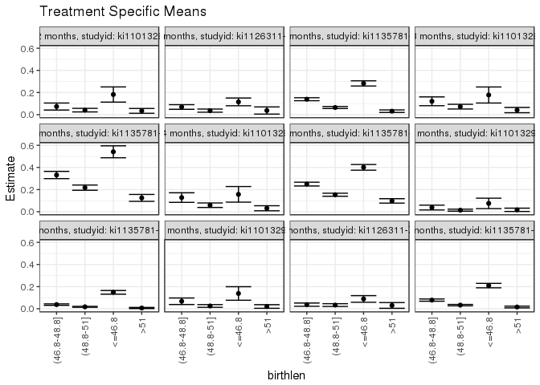

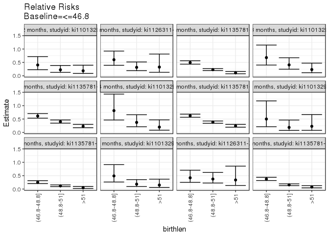

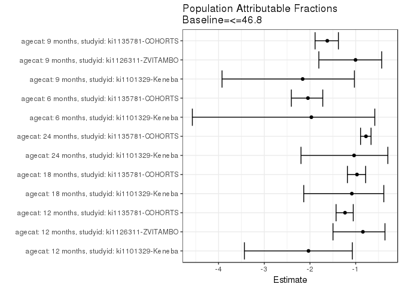

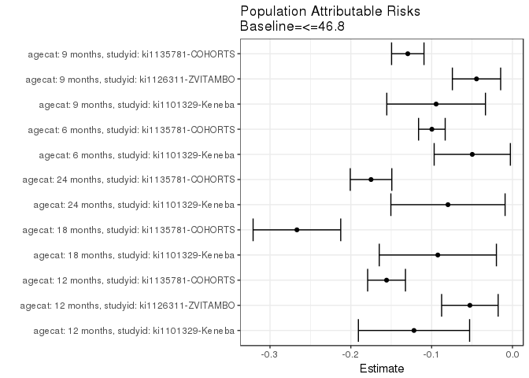

## Data Summary

| agecat | studyid | A | n | nA | nAY0 | nAY1 |
| --- | --- | --- | --- | --- | --- | --- |
| Birth | ki0047075b-MAL-ED | <=46.8 | 54 | 20 | 19 | 1 |
| Birth | ki0047075b-MAL-ED | (46.8-48.8] | 54 | 23 | 23 | 0 |
| Birth | ki0047075b-MAL-ED | (48.8-51] | 54 | 11 | 11 | 0 |
| Birth | ki0047075b-MAL-ED | >51 | 54 | 0 | 0 | 0 |
| Birth | ki1000108-CMC-V-BCS-2002 | <=46.8 | 89 | 22 | 19 | 3 |
| Birth | ki1000108-CMC-V-BCS-2002 | (46.8-48.8] | 89 | 32 | 32 | 0 |
| Birth | ki1000108-CMC-V-BCS-2002 | (48.8-51] | 89 | 34 | 34 | 0 |
| Birth | ki1000108-CMC-V-BCS-2002 | >51 | 89 | 1 | 1 | 0 |
| Birth | ki1000108-IRC | <=46.8 | 388 | 65 | 49 | 16 |
| Birth | ki1000108-IRC | (46.8-48.8] | 388 | 107 | 107 | 0 |
| Birth | ki1000108-IRC | (48.8-51] | 388 | 143 | 143 | 0 |
| Birth | ki1000108-IRC | >51 | 388 | 73 | 73 | 0 |
| Birth | ki1017093b-PROVIDE | <=46.8 | 0 | 0 | 0 | 0 |
| Birth | ki1017093b-PROVIDE | (46.8-48.8] | 0 | 0 | 0 | 0 |
| Birth | ki1017093b-PROVIDE | (48.8-51] | 0 | 0 | 0 | 0 |
| Birth | ki1017093b-PROVIDE | >51 | 0 | 0 | 0 | 0 |
| Birth | ki1017093c-NIH-Crypto | <=46.8 | 27 | 11 | 10 | 1 |
| Birth | ki1017093c-NIH-Crypto | (46.8-48.8] | 27 | 10 | 10 | 0 |
| Birth | ki1017093c-NIH-Crypto | (48.8-51] | 27 | 6 | 6 | 0 |
| Birth | ki1017093c-NIH-Crypto | >51 | 27 | 0 | 0 | 0 |
| Birth | ki1101329-Keneba | <=46.8 | 1541 | 143 | 114 | 29 |
| Birth | ki1101329-Keneba | (46.8-48.8] | 1541 | 337 | 337 | 0 |
| Birth | ki1101329-Keneba | (48.8-51] | 1541 | 730 | 730 | 0 |
| Birth | ki1101329-Keneba | >51 | 1541 | 331 | 331 | 0 |
| Birth | ki1126311-ZVITAMBO | <=46.8 | 3449 | 613 | 501 | 112 |
| Birth | ki1126311-ZVITAMBO | (46.8-48.8] | 3449 | 1095 | 1095 | 0 |
| Birth | ki1126311-ZVITAMBO | (48.8-51] | 3449 | 1410 | 1410 | 0 |
| Birth | ki1126311-ZVITAMBO | >51 | 3449 | 331 | 331 | 0 |
| Birth | ki1135781-COHORTS | <=46.8 | 10097 | 2015 | 1759 | 256 |
| Birth | ki1135781-COHORTS | (46.8-48.8] | 10097 | 3341 | 3341 | 0 |

[output cut: 194 more lines]

## Results Table

### Parameter: TSM

| agecat | studyid | intervention_level | baseline_level | estimate | ci_lower | ci_upper |
| --- | --- | --- | --- | --- | --- | --- |
| 6 months | ki1101329-Keneba | <=46.8 | NA | 0.0750000 | 0.0278567 | 0.1221433 |
| 6 months | ki1101329-Keneba | (46.8-48.8] | NA | 0.0375427 | 0.0157691 | 0.0593162 |
| 6 months | ki1101329-Keneba | (48.8-51] | NA | 0.0140406 | 0.0049288 | 0.0231523 |
| 6 months | ki1101329-Keneba | >51 | NA | 0.0171233 | 0.0022379 | 0.0320087 |
| 6 months | ki1135781-COHORTS | <=46.8 | NA | 0.1484983 | 0.1320610 | 0.1649356 |
| 6 months | ki1135781-COHORTS | (46.8-48.8] | NA | 0.0376432 | 0.0308936 | 0.0443928 |
| 6 months | ki1135781-COHORTS | (48.8-51] | NA | 0.0175918 | 0.0131042 | 0.0220793 |
| 6 months | ki1135781-COHORTS | >51 | NA | 0.0069034 | 0.0018068 | 0.0119999 |
| 9 months | ki1101329-Keneba | <=46.8 | NA | 0.1382114 | 0.0771971 | 0.1992257 |
| 9 months | ki1101329-Keneba | (46.8-48.8] | NA | 0.0678571 | 0.0383877 | 0.0973266 |
| 9 months | ki1101329-Keneba | (48.8-51] | NA | 0.0253165 | 0.0130650 | 0.0375679 |
| 9 months | ki1101329-Keneba | >51 | NA | 0.0206186 | 0.0042854 | 0.0369517 |
| 9 months | ki1126311-ZVITAMBO | <=46.8 | NA | 0.0888252 | 0.0589703 | 0.1186802 |
| 9 months | ki1126311-ZVITAMBO | (46.8-48.8] | NA | 0.0373250 | 0.0226697 | 0.0519803 |
| 9 months | ki1126311-ZVITAMBO | (48.8-51] | NA | 0.0332481 | 0.0206792 | 0.0458170 |
| 9 months | ki1126311-ZVITAMBO | >51 | NA | 0.0301205 | 0.0041131 | 0.0561278 |
| 9 months | ki1135781-COHORTS | <=46.8 | NA | 0.2094340 | 0.1894322 | 0.2294357 |
| 9 months | ki1135781-COHORTS | (46.8-48.8] | NA | 0.0784884 | 0.0684398 | 0.0885369 |
| 9 months | ki1135781-COHORTS | (48.8-51] | NA | 0.0328794 | 0.0265097 | 0.0392492 |
| 9 months | ki1135781-COHORTS | >51 | NA | 0.0158898 | 0.0079123 | 0.0238674 |
| 12 months | ki1101329-Keneba | <=46.8 | NA | 0.1818182 | 0.1130678 | 0.2505685 |
| 12 months | ki1101329-Keneba | (46.8-48.8] | NA | 0.0733591 | 0.0415935 | 0.1051247 |
| 12 months | ki1101329-Keneba | (48.8-51] | NA | 0.0406780 | 0.0247317 | 0.0566243 |
| 12 months | ki1101329-Keneba | >51 | NA | 0.0340909 | 0.0121927 | 0.0559892 |
| 12 months | ki1126311-ZVITAMBO | <=46.8 | NA | 0.1152648 | 0.0803202 | 0.1502094 |
| 12 months | ki1126311-ZVITAMBO | (46.8-48.8] | NA | 0.0692718 | 0.0482914 | 0.0902521 |
| 12 months | ki1126311-ZVITAMBO | (48.8-51] | NA | 0.0363086 | 0.0220443 | 0.0505729 |
| 12 months | ki1126311-ZVITAMBO | >51 | NA | 0.0375940 | 0.0052577 | 0.0699303 |
| 12 months | ki1135781-COHORTS | <=46.8 | NA | 0.2821229 | 0.2588125 | 0.3054333 |
| 12 months | ki1135781-COHORTS | (46.8-48.8] | NA | 0.1393410 | 0.1258166 | 0.1528654 |
| 12 months | ki1135781-COHORTS | (48.8-51] | NA | 0.0644928 | 0.0553284 | 0.0736571 |
| 12 months | ki1135781-COHORTS | >51 | NA | 0.0312500 | 0.0198566 | 0.0426434 |
| 18 months | ki1101329-Keneba | <=46.8 | NA | 0.1775701 | 0.1051312 | 0.2500090 |
| 18 months | ki1101329-Keneba | (46.8-48.8] | NA | 0.1206226 | 0.0807876 | 0.1604576 |
| 18 months | ki1101329-Keneba | (48.8-51] | NA | 0.0723104 | 0.0509829 | 0.0936379 |
| 18 months | ki1101329-Keneba | >51 | NA | 0.0413534 | 0.0174162 | 0.0652906 |
| 18 months | ki1135781-COHORTS | <=46.8 | NA | 0.5412844 | 0.4872665 | 0.5953023 |
| 18 months | ki1135781-COHORTS | (46.8-48.8] | NA | 0.3316646 | 0.2990133 | 0.3643159 |
| 18 months | ki1135781-COHORTS | (48.8-51] | NA | 0.2173547 | 0.1938871 | 0.2408223 |
| 18 months | ki1135781-COHORTS | >51 | NA | 0.1247113 | 0.0935861 | 0.1558365 |
| 24 months | ki1101329-Keneba | <=46.8 | NA | 0.1568627 | 0.0862536 | 0.2274719 |
| 24 months | ki1101329-Keneba | (46.8-48.8] | NA | 0.1277533 | 0.0843078 | 0.1711988 |
| 24 months | ki1101329-Keneba | (48.8-51] | NA | 0.0587084 | 0.0383167 | 0.0791001 |
| 24 months | ki1101329-Keneba | >51 | NA | 0.0312500 | 0.0084540 | 0.0540460 |
| 24 months | ki1135781-COHORTS | <=46.8 | NA | 0.4008529 | 0.3752441 | 0.4264617 |
| 24 months | ki1135781-COHORTS | (46.8-48.8] | NA | 0.2495002 | 0.2325400 | 0.2664604 |
| 24 months | ki1135781-COHORTS | (48.8-51] | NA | 0.1533062 | 0.1397332 | 0.1668793 |
| 24 months | ki1135781-COHORTS | >51 | NA | 0.0976471 | 0.0776905 | 0.1176036 |

### Parameter: E(Y)

| agecat | studyid | intervention_level | baseline_level | estimate | ci_lower | ci_upper |
| --- | --- | --- | --- | --- | --- | --- |
| 6 months | ki1101329-Keneba | NA | NA | 0.0252600 | 0.0242926 | 0.0262275 |
| 6 months | ki1135781-COHORTS | NA | NA | 0.0487778 | 0.0477467 | 0.0498090 |
| 9 months | ki1101329-Keneba | NA | NA | 0.0437406 | 0.0418523 | 0.0456288 |
| 9 months | ki1126311-ZVITAMBO | NA | NA | 0.0443299 | 0.0433971 | 0.0452627 |
| 9 months | ki1135781-COHORTS | NA | NA | 0.0799084 | 0.0784674 | 0.0813494 |
| 12 months | ki1101329-Keneba | NA | NA | 0.0599676 | 0.0575898 | 0.0623453 |
| 12 months | ki1126311-ZVITAMBO | NA | NA | 0.0625745 | 0.0611649 | 0.0639841 |
| 12 months | ki1135781-COHORTS | NA | NA | 0.1263310 | 0.1244404 | 0.1282216 |
| 18 months | ki1101329-Keneba | NA | NA | 0.0852130 | 0.0829904 | 0.0874356 |
| 18 months | ki1135781-COHORTS | NA | NA | 0.2745812 | 0.2700959 | 0.2790665 |
| 24 months | ki1101329-Keneba | NA | NA | 0.0770677 | 0.0745441 | 0.0795913 |
| 24 months | ki1135781-COHORTS | NA | NA | 0.2258540 | 0.2236151 | 0.2280929 |

### Parameter: RR

| agecat | studyid | intervention_level | baseline_level | estimate | ci_lower | ci_upper |
| --- | --- | --- | --- | --- | --- | --- |
| 6 months | ki1101329-Keneba | (46.8-48.8] | <=46.8 | 0.5005688 | 0.2128278 | 1.1773329 |
| 6 months | ki1101329-Keneba | (48.8-51] | <=46.8 | 0.1872075 | 0.0758492 | 0.4620569 |
| 6 months | ki1101329-Keneba | >51 | <=46.8 | 0.2283105 | 0.0780968 | 0.6674494 |
| 6 months | ki1135781-COHORTS | (46.8-48.8] | <=46.8 | 0.2534925 | 0.2053294 | 0.3129529 |
| 6 months | ki1135781-COHORTS | (48.8-51] | <=46.8 | 0.1184643 | 0.0897058 | 0.1564424 |
| 6 months | ki1135781-COHORTS | >51 | <=46.8 | 0.0464877 | 0.0220356 | 0.0980734 |
| 9 months | ki1101329-Keneba | (46.8-48.8] | <=46.8 | 0.4909664 | 0.2643070 | 0.9120002 |
| 9 months | ki1101329-Keneba | (48.8-51] | <=46.8 | 0.1831720 | 0.0951437 | 0.3526452 |
| 9 months | ki1101329-Keneba | >51 | <=46.8 | 0.1491813 | 0.0602378 | 0.3694535 |
| 9 months | ki1126311-ZVITAMBO | (46.8-48.8] | <=46.8 | 0.4202077 | 0.2506100 | 0.7045789 |
| 9 months | ki1126311-ZVITAMBO | (48.8-51] | <=46.8 | 0.3743091 | 0.2257068 | 0.6207489 |
| 9 months | ki1126311-ZVITAMBO | >51 | <=46.8 | 0.3390983 | 0.1342542 | 0.8564920 |
| 9 months | ki1135781-COHORTS | (46.8-48.8] | <=46.8 | 0.3747643 | 0.3194414 | 0.4396684 |
| 9 months | ki1135781-COHORTS | (48.8-51] | <=46.8 | 0.1569919 | 0.1264950 | 0.1948414 |
| 9 months | ki1135781-COHORTS | >51 | <=46.8 | 0.0758704 | 0.0455117 | 0.1264799 |
| 12 months | ki1101329-Keneba | (46.8-48.8] | <=46.8 | 0.4034749 | 0.2270655 | 0.7169385 |
| 12 months | ki1101329-Keneba | (48.8-51] | <=46.8 | 0.2237288 | 0.1297714 | 0.3857134 |
| 12 months | ki1101329-Keneba | >51 | <=46.8 | 0.1875000 | 0.0889788 | 0.3951081 |
| 12 months | ki1126311-ZVITAMBO | (46.8-48.8] | <=46.8 | 0.6009793 | 0.3915161 | 0.9225064 |
| 12 months | ki1126311-ZVITAMBO | (48.8-51] | <=46.8 | 0.3150018 | 0.1917784 | 0.5174000 |
| 12 months | ki1126311-ZVITAMBO | >51 | <=46.8 | 0.3261532 | 0.1310211 | 0.8118992 |
| 12 months | ki1135781-COHORTS | (46.8-48.8] | <=46.8 | 0.4939018 | 0.4347935 | 0.5610456 |
| 12 months | ki1135781-COHORTS | (48.8-51] | <=46.8 | 0.2285981 | 0.1939482 | 0.2694384 |
| 12 months | ki1135781-COHORTS | >51 | <=46.8 | 0.1107673 | 0.0762180 | 0.1609777 |
| 18 months | ki1101329-Keneba | (46.8-48.8] | <=46.8 | 0.6792955 | 0.4018959 | 1.1481641 |
| 18 months | ki1101329-Keneba | (48.8-51] | <=46.8 | 0.4072218 | 0.2461542 | 0.6736816 |
| 18 months | ki1101329-Keneba | >51 | <=46.8 | 0.2328849 | 0.1147081 | 0.4728119 |
| 18 months | ki1135781-COHORTS | (46.8-48.8] | <=46.8 | 0.6127363 | 0.5325904 | 0.7049427 |
| 18 months | ki1135781-COHORTS | (48.8-51] | <=46.8 | 0.4015536 | 0.3466499 | 0.4651531 |
| 18 months | ki1135781-COHORTS | >51 | <=46.8 | 0.2303989 | 0.1760946 | 0.3014495 |
| 24 months | ki1101329-Keneba | (46.8-48.8] | <=46.8 | 0.8144273 | 0.4632796 | 1.4317313 |
| 24 months | ki1101329-Keneba | (48.8-51] | <=46.8 | 0.3742661 | 0.2119612 | 0.6608527 |
| 24 months | ki1101329-Keneba | >51 | <=46.8 | 0.1992188 | 0.0845402 | 0.4694583 |
| 24 months | ki1135781-COHORTS | (46.8-48.8] | <=46.8 | 0.6224234 | 0.5669861 | 0.6832810 |
| 24 months | ki1135781-COHORTS | (48.8-51] | <=46.8 | 0.3824501 | 0.3428936 | 0.4265700 |
| 24 months | ki1135781-COHORTS | >51 | <=46.8 | 0.2435983 | 0.1966437 | 0.3017646 |

### Parameter: PAR

| agecat | studyid | intervention_level | baseline_level | estimate | ci_lower | ci_upper |
| --- | --- | --- | --- | --- | --- | --- |
| 6 months | ki1101329-Keneba | <=46.8 | NA | -0.0497400 | -0.0968932 | -0.0025867 |
| 6 months | ki1135781-COHORTS | <=46.8 | NA | -0.0997205 | -0.1161901 | -0.0832509 |
| 9 months | ki1101329-Keneba | <=46.8 | NA | -0.0944708 | -0.1555143 | -0.0334273 |
| 9 months | ki1126311-ZVITAMBO | <=46.8 | NA | -0.0444953 | -0.0743648 | -0.0146258 |
| 9 months | ki1135781-COHORTS | <=46.8 | NA | -0.1295256 | -0.1495792 | -0.1094720 |
| 12 months | ki1101329-Keneba | <=46.8 | NA | -0.1218506 | -0.1906421 | -0.0530591 |
| 12 months | ki1126311-ZVITAMBO | <=46.8 | NA | -0.0526903 | -0.0876633 | -0.0177173 |
| 12 months | ki1135781-COHORTS | <=46.8 | NA | -0.1557919 | -0.1791788 | -0.1324050 |
| 18 months | ki1101329-Keneba | <=46.8 | NA | -0.0923571 | -0.1648301 | -0.0198840 |
| 18 months | ki1135781-COHORTS | <=46.8 | NA | -0.2667032 | -0.3209070 | -0.2124994 |
| 24 months | ki1101329-Keneba | <=46.8 | NA | -0.0797951 | -0.1504493 | -0.0091408 |
| 24 months | ki1135781-COHORTS | <=46.8 | NA | -0.1749989 | -0.2007054 | -0.1492924 |

### Parameter: PAF

| agecat | studyid | intervention_level | baseline_level | estimate | ci_lower | ci_upper |
| --- | --- | --- | --- | --- | --- | --- |
| 6 months | ki1101329-Keneba | <=46.8 | NA | -1.9691176 | -4.5734178 | -0.5817331 |
| 6 months | ki1135781-COHORTS | <=46.8 | NA | -2.0443819 | -2.4075334 | -1.7199326 |
| 9 months | ki1101329-Keneba | <=46.8 | NA | -2.1597981 | -3.9237490 | -1.0277891 |
| 9 months | ki1126311-ZVITAMBO | <=46.8 | NA | -1.0037316 | -1.8060512 | -0.4308151 |
| 9 months | ki1135781-COHORTS | <=46.8 | NA | -1.6209255 | -1.8884474 | -1.3781808 |
| 12 months | ki1101329-Keneba | <=46.8 | NA | -2.0319410 | -3.4344484 | -1.0730124 |
| 12 months | ki1126311-ZVITAMBO | <=46.8 | NA | -0.8420412 | -1.4964707 | -0.3591651 |
| 12 months | ki1135781-COHORTS | <=46.8 | NA | -1.2332039 | -1.4288225 | -1.0533405 |
| 18 months | ki1101329-Keneba | <=46.8 | NA | -1.0838373 | -2.1361301 | -0.3846293 |
| 18 months | ki1135781-COHORTS | <=46.8 | NA | -0.9713090 | -1.1810833 | -0.7817106 |
| 24 months | ki1101329-Keneba | <=46.8 | NA | -1.0353898 | -2.1963528 | -0.2961058 |
| 24 months | ki1135781-COHORTS | <=46.8 | NA | -0.7748320 | -0.8933658 | -0.6637190 |